# R Notebook

## we can do better

1. establish the frame
2. plot the glyphs (i.e., select a geom)
3. map the aesthetics
4. add labels and title
5. other features (e.g., alpha, sizing, etc)
6. Establish the Frame

Nothing is here! That is exactly what is supposed to happen. Calling `ggplot()` only tells us R that we are ready to plot and I want you to call some space to create my plot.

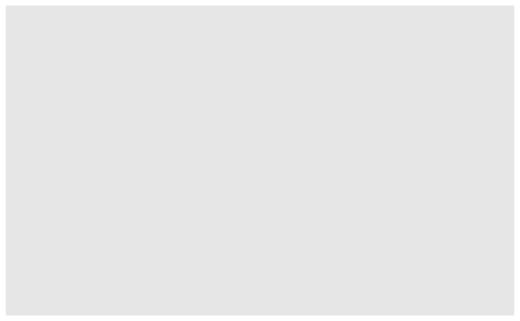

2. plot the glyphs (i.e., select a geom)

Still Nothing! We need to tell it what our axis are.

Note that ggplot uses `+`, NOT `%>%`. This is because we are **adding** layers to our plots.

```r
ggplot(data = Names) +
  geom_line()
```

[output not shown]

3. Map the aesthetics

Rule of thumb: anytime when you are plotting with ggplot, ALL variables need to be insdie an `aes`.

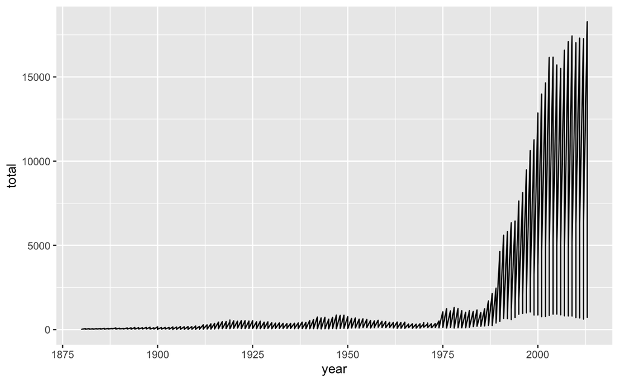

```r
#not Quite
ggplot(data = Names) +
  geom_line( aes(x = year, y = total))
```

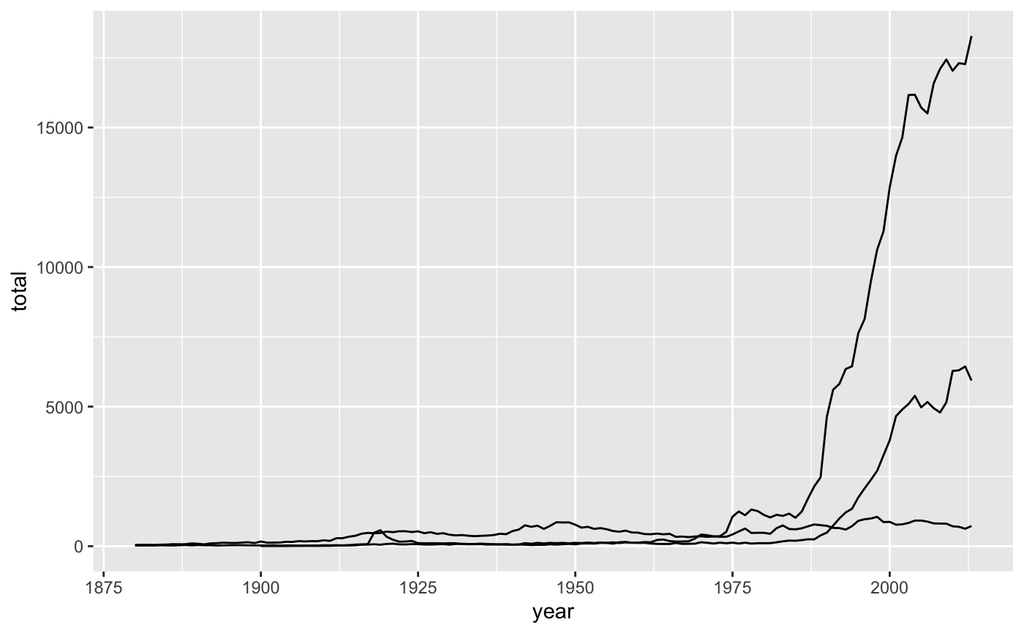

```r
#add groups
ggplot(data = Names) +
  geom_line( aes(x = year, y = total, group = name))
```

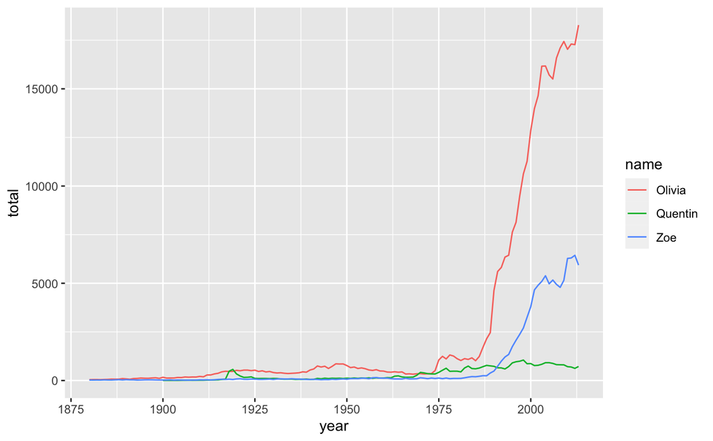

```r
#add color
ggplot(data = Names) +
  geom_line( aes(x = year, y = total, color = name))
```

```r
NA
NA
```

4. Add labels and title

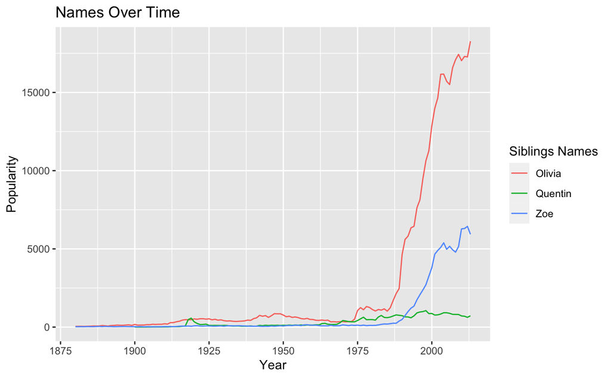

5. other features (e.g., alpha, sizing, etc)

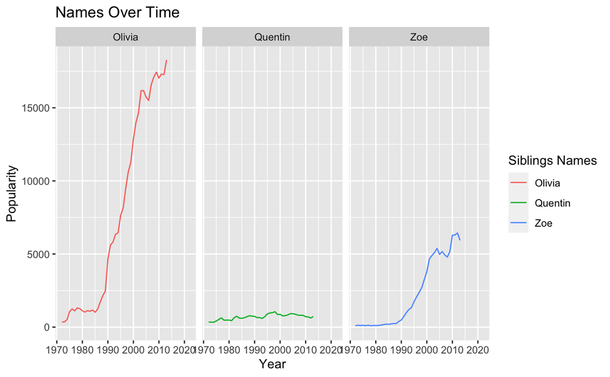

```r
ggplot(data = Names) +
  geom_line( aes(x = year, y = total, color = name)) +
  ggtitle("Names Over Time") +
  xlim(c(1972, 2022))+
  facet_wrap( ~ name) +
  xlab("Year") +
  ylab("Popularity") +
  guides(color = guide_legend(title = "Siblings Names" ))
```

## Lets overlay the overall birth trend

- First we need to calculate the total number of US births each year and even
- plot it (by itself)
- can we add that as a layer to the main plot?
- clean up & polish

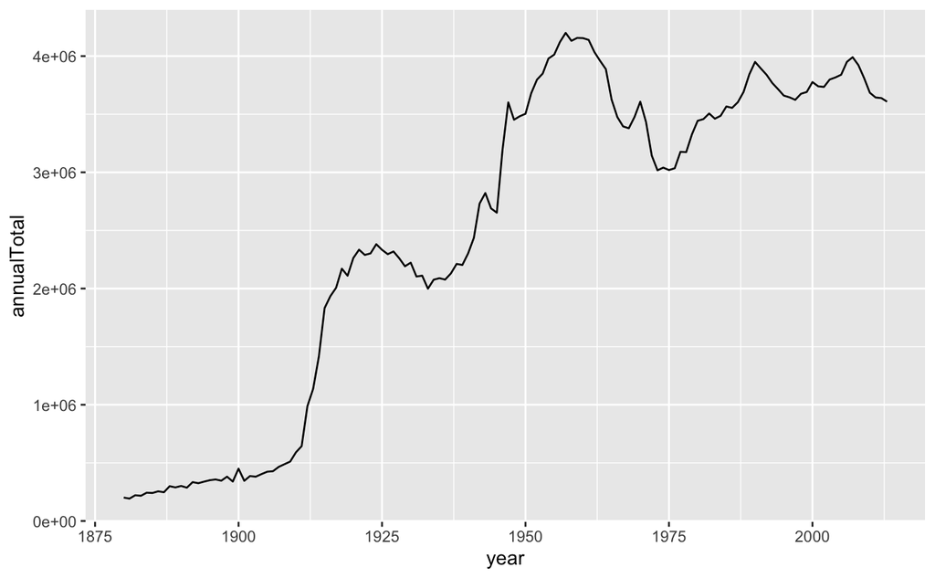

```r
AnnualBirths <-
  BabyNames %>%
  group_by(year) %>%
  summarise(annualTotal = sum(count, na.rm = TRUE))

# plot the annual birth trend
AnnualBirths %>%
  ggplot() +
  geom_line(aes(x = year, y = annualTotal))
```

```r
NA
```

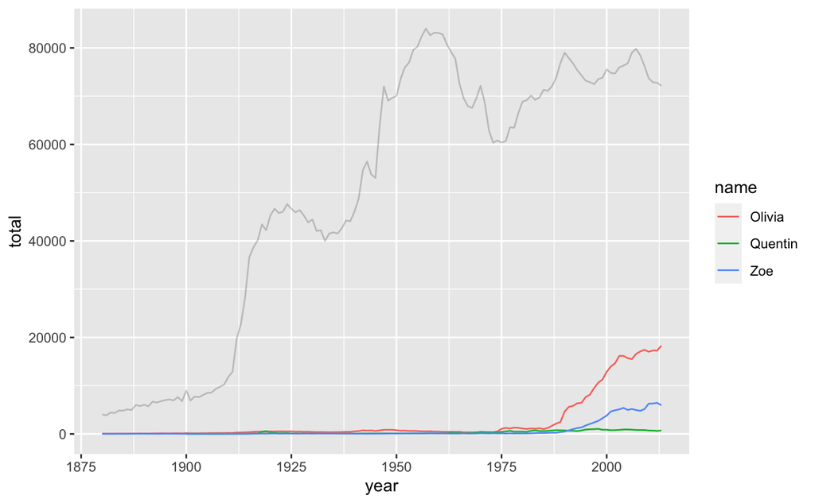

```r
Names %>%
  ggplot() +
  geom_line(aes(x = year, y = total, color = name)) +
  geom_line(data = AnnualBirths, aes(x = year, y = annualTotal / 50), alpha = 0.20)
```

```r
NA
```

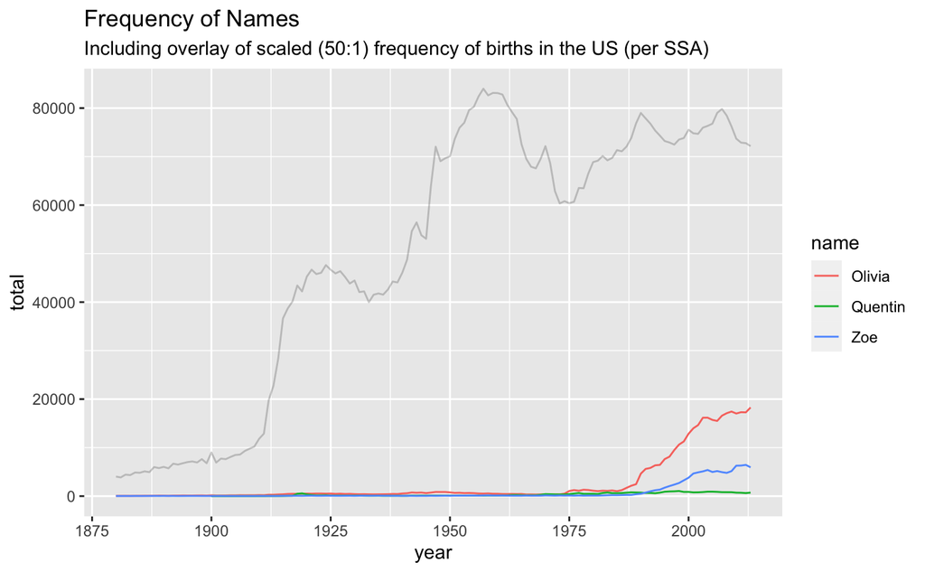

```r
Names %>%
  ggplot(aes(x = year)) +
  geom_line(aes(y = total, color = name)) +
  geom_line(data = AnnualBirths, aes(y = annualTotal / 50), alpha = 0.20) +
  ggtitle(label = "Frequency of Names",
          subtitle = "Including overlay of scaled (50:1) frequency of births in the US (per SSA)")
```

```r
NA
NA
```

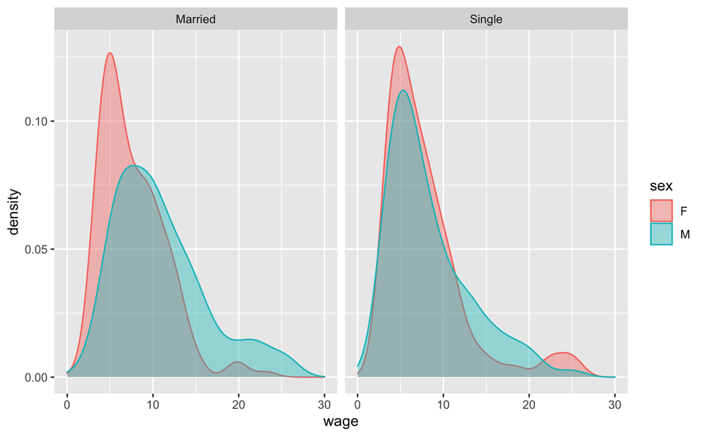

```r
library(mosaicData)
CPS85 %>%
  ggplot() +
  geom_density(aes(x=wage,color=sex,fill=sex),alpha=0.4)+
  facet_grid(~married) +
   xlim(0,30)
```

```r
NA
NA
```